# Entrega 1 - Talleres 1

Author

Patricia del Amo Martín

# Primera entrega evaluable

Elabora un documento, a poder ser un html con RMarkdown—alternativamente entregando un Word y un script de R—, donde muestres como has trabajado con la base de datos del [QoG](https://www.gu.se/en/quality-government/qog-data/data-downloads/standard-dataset) con información a nivel de país. Usa el link anterior para descargarte el libro de códigos aunque recuerda que los datos que vas a usar son una versión simplificada de la base de datos. Es importante entregar los detalles con todos los pasos seguidos para modificar la base de datos de acuerdo con lo requerido, incluye también una breve descripción de los resultados obtenidos. Para hacer este ejercicio es crucial trabajar con los paquetes de tidyverse y usar la pipa de R ( |> o %>% ).

## Ejercicio 1

###### Carga la base de datos del QoG (se corresponde con la versión simple o Cross-section de los datos del QoG) que encontrarás en [la carpeta de GitHub con el nombre `qog_simple`](https://github.com/pauvallprat/24-25_mape_talleres1/tree/main/1_datos). Guárdala en la carpeta donde guardes las bases de datos de la asignatura y cárgala en el ambiente de R en un objeto que lleve el nombre `qog`.

```r
library(pacman)
p_load(tidyverse)
qog <- read_rds("qog_simple.rds")
```

## Ejercicio 2

###### Indica las características principales de este objeto, qué información contiene la base de datos, cuantas observaciones y variables tiene.

```r
#Este objeto es una base de datos y cuenta con información económica, demográfica y política a nivel de país. Se encuentran países de diferentes partes del mundo, por lo que el ámbito de las naciones que aparecen es mundial.
#Tiene 194 observaciones y 50 variables. Generalmente, son variables numéricas y, en particular, continuas, a excepción de variables como nombre de país, región, continente, etc., que son cadenas de texto.

dim(qog)
```

```
[1] 194  50
```

## Ejercicio 3

###### Crea dos objetos que contengan solo una parte de la información del objeto `qog`.

###### a. Un objeto con datos únicamente de los países europeos

```r
europe <- filter(qog, continent == "Europe")
```

###### b. Un objeto con datos de los países con una población superior a 100 millones de habitantes

```r
bigpop <- filter(qog, pwt_pop > 100)
```

#### Ejercicio 4

###### En este nuevo objeto con los países más poblados, elimina la variable de mortalidad infantil

```r
bigpop <- bigpop %>%
  select(-wdi_mortinf)
```

## Ejercicio 5

###### En el objeto con los países más poblados, elige cuatro de las variables que consideres más relevantes para analizar políticamente estos países

```r
bigpop <- bigpop %>%
  select(cname,bmr_dem,cpds_chg,cpds_enps)
```

## Ejercicio 6

###### Crea una variable dicotómica que distinga los países europeos entre los que tienen más de un 25% de escaños ocupados por diputados socialdemócratas y los que no. Haz una tabla simple para ver cuántos países cumplen con esta condición y cuáles no.

```r
europe <- europe %>%
  mutate(socialdemocratic = factor(if_else(cpds_ls > 25, "Cumplen", "No cumplen")))
table(europe$socialdemocratic)
```

```
   Cumplen No cumplen
        11         19
```

## Ejercicio 7

###### Calcula, en la base de datos global, el porcentaje de la población en cada país que es refugiada. (Recuerda que es importante que la escala de las variables sea la misma.)

```r
qog <- qog %>%
  mutate(refugees = (wdi_refasy / (pwt_pop * 1000000)) * 100)
```

## Ejercicio 8

###### Ordena los países de menor a mayor porcentaje de mujeres en el parlamento. Muestra los países con menores porcentajes

```r
qog %>%
  arrange(wdi_wip) %>%
  select(cname, wdi_wip) %>%
  head(n = 10) #Pongo 10 como ejemplo.
```

```
# A tibble: 10 × 2
   cname                            wdi_wip
   <chr>                              <dbl>
 1 Vanuatu                            0
 2 Micronesia (Federated States of)   0
 3 Papua New Guinea                   0
 4 Yemen                              0.332
 5 Oman                               2.33
 6 Haiti                              2.54
 7 Nigeria                            3.38
 8 Solomon Islands                    4.08
 9 Maldives                           4.60
10 Kuwait                             4.62
```

## Ejercicio 9

###### Ordena de mayor a menor el porcentaje de población refugiada y rea un nuevo marco de datos con las variables del nombre del país y la variable de porcentaje de población refugiada. Indica los 5 países con mayor población refugiada en términos relativos.

```r
qog <- qog %>%
  arrange(desc(refugees)) #primero ordeno en qog

refugees <- qog %>%       #ahora ya sí creo el marco de datos
  select(cname, refugees)
  head(refugees, 5)
```

```
# A tibble: 5 × 2
  cname                      refugees
  <chr>                         <dbl>
1 Jordan                        29.4
2 Lebanon                       20.3
3 Turkey                         4.29
4 Syrian Arab Republic (the)     3.39
5 Uganda                         3.07
```

## Ejercicio 10

###### Presenta la suma de casos de Covid en el mundo

```r
sum(qog$jht_ccc, na.rm = TRUE)
```

```
[1] 83586140
```

## Ejercicio 11

###### Indica la población mundial por continentes

```r
qog %>%
  filter(!is.na(continent)) %>% #para que no aparezca "NA" en la tabla
  group_by(continent) %>%
  summarize(world_pop=sum(pwt_pop, na.rm = TRUE)) #ungroup no es necesario
```

```
# A tibble: 6 × 2
  continent     world_pop
  <chr>             <dbl>
1 Africa           1268.
2 Asia             4523.
3 Europe            747.
4 North America     572.
5 Oceania            30.9
6 South America     427.
```

## Ejercicio 12

###### Indica el valor máximo en el número de ministros en el gabinete por regiones (`region1`).

```r
qog %>%
  group_by(region1) %>%
  summarize(max_minister = max(wgov_min, na.rm = TRUE)) #ungroup no es necesario
```

```
# A tibble: 23 × 2
   region1                   max_minister
   <chr>                            <dbl>
 1 Australia and New Zealand           30
 2 Caribbean                           23
 3 Central America                     24
 4 Central Asia                        21
 5 Eastern Africa                      30
 6 Eastern Asia                        39
 7 Eastern Europe                      25
 8 Melanesia                           32
 9 Micronesia                        -Inf
10 Middle Africa                       41
# ℹ 13 more rows
```

## Ejercicio 13

###### Presenta el valor de fragmentación étnica media por continentes

```r
qog %>%
  filter(!is.na(continent)) %>%
  group_by(continent) %>%
  summarize(mean_ethnicfrag = mean(al_ethnic2000, na.rm = TRUE)) #ungroup no es necesario
```

```
# A tibble: 6 × 2
  continent     mean_ethnicfrag
  <chr>                   <dbl>
1 Africa                  0.629
2 Asia                    0.416
3 Europe                  0.300
4 North America           0.376
5 Oceania                 0.263
6 South America           0.492
```

## Ejercicio 14

###### La esperanza de vida, ¿es mayor en las democracias que en los países no democráticos? Justifica tu respuesta.

```r
qog %>%
  group_by(bmr_dem) %>%
  summarize(lifexp_democracy = mean(wdi_lifexp, na.rm = TRUE)) #ungroup no es necesario
```

```
# A tibble: 2 × 2
  bmr_dem lifexp_democracy
    <dbl>            <dbl>
1       0             69.1
2       1             74.6
```

```r
attr(qog$bmr_dem, "labels")
```

```r
#Arroja NULL. En el codebook tampoco se especifica. Es cierto que, normalmente, suele ser 1 para democracias y 0 para no democracias.
#Vamos a ver el caso de España para salir de dudas.
qog %>%
  filter(cname == "Spain") %>%
  pull(bmr_dem) %>%
  as.numeric()
```

```
[1] 1
```

```r
#Por tanto, volviendo al ejercicio 14, la esperanza de vida es mayor en las democracias porque el valor medio de la esperanza de vida es mayor en la categoría 1 de "bmr_dem", que es democracia, en comparación con la categoría 0.
```

## Ejercicio 15

###### Indica cuantos países tienen una letra K en su nombre

```r
# Entiendo que, como no se especifica, puede ser tanto mayúscula como minúscula. En ese caso:
qog %>%
  filter(str_detect(cname, "[Kk]")) %>%
  select(cname)
```

```
# A tibble: 19 × 1
   cname
   <chr>
 1 Turkey
 2 Kenya
 3 Pakistan
 4 Denmark
 5 United Kingdom of Great Britain and Northern Ireland (the)
 6 Burkina Faso
 7 Tajikistan
 8 Slovakia
 9 Kuwait
10 Saint Kitts and Nevis
11 Korea (the Republic of)
12 Kyrgyzstan
13 Ukraine
14 Sri Lanka
15 Kazakhstan
16 Turkmenistan
17 Uzbekistan
18 Kiribati
19 Korea (the Democratic People's Republic of)
```

```r
# 19 países.
```

## Ejercicio 16

###### Crea una nueva variable que elimine el texto “(the)” al final del nombre de los países y muestra en una tabla las dos variables, la original y la nueva para estos países.

```r
qog %>%
  mutate(eliminate_the = str_remove(cname, "\\(the\\)$")) %>%
  filter(str_detect(cname, "\\(the\\)$")) %>% #para estos países
  select(cname, eliminate_the)
```

```
# A tibble: 16 × 2
   cname                                                      eliminate_the
   <chr>                                                      <chr>
 1 Syrian Arab Republic (the)                                 "Syrian Arab Repu…
 2 Sudan (the)                                                "Sudan "
 3 Niger (the)                                                "Niger "
 4 Netherlands (the)                                          "Netherlands "
 5 Congo (the)                                                "Congo "
 6 United Kingdom of Great Britain and Northern Ireland (the) "United Kingdom o…
 7 Gambia (the)                                               "Gambia "
 8 Central African Republic (the)                             "Central African …
 9 United States of America (the)                             "United States of…
10 Russian Federation (the)                                   "Russian Federati…
11 United Arab Emirates (the)                                 "United Arab Emir…
12 Comoros (the)                                              "Comoros "
13 Bahamas (the)                                              "Bahamas "
14 Dominican Republic (the)                                   "Dominican Republ…
15 Philippines (the)                                          "Philippines "
16 Lao People's Democratic Republic (the)                     "Lao People's Dem…
```

## Ejercicio 17

###### Homogeneiza el estilo de texto en la variable `continent` para que el texto aparezca en mayúsculas y asegúrate que no hay espacios en blanco extra.

```r
qog %>%
  mutate(continent = str_to_upper(str_trim(continent)))
```

```
# A tibble: 194 × 51
   cname     ccodealp region1 region2 continent pwt_pop wdi_migration wdi_refasy
   <chr>     <chr>    <chr>   <chr>   <chr>       <dbl>         <dbl>      <dbl>
 1 Jordan    JOR      Wester… <NA>    ASIA       10.1           28963    2966079
 2 Lebanon   LBN      Wester… <NA>    ASIA        6.86        -237572    1392174
 3 Turkey    TUR      Wester… <NA>    ASIA       83.4         -218341    3579531
 4 Syrian A… SYR      Wester… <NA>    ASIA       17.1          500572     578525
 5 Uganda    UGA      Easter… Sub-Sa… AFRICA     44.3          107203    1359458
 6 Chad      TCD      Middle… Sub-Sa… AFRICA     15.9           -9469     442670
 7 Sweden    SWE      Northe… <NA>    EUROPE     10.0           81585     253787
 8 Sudan (t… SDN      Northe… <NA>    AFRICA     42.8          -29450    1055489
 9 Malta     MLT      Southe… <NA>    EUROPE      0.440         11247       8908
10 Djibouti  DJI      Easter… Sub-Sa… AFRICA      0.974          1322      19639
# ℹ 184 more rows
# ℹ 43 more variables: wdi_litrad <dbl>, pwt_rgdp <dbl>, wdi_unempedub <dbl>,
#   bmr_dem <dbl>, wdi_wip <dbl>, cpds_chg <dbl>, cpds_enps <dbl>,
#   cpds_enpv <dbl>, cpds_frel <dbl>, cpds_frleg <dbl>, cpds_govlr <hvn_lbll>,
#   cpds_govsup <dbl>, cpds_la <dbl>, cpds_lall <dbl>, cpds_lcom <dbl>,
#   cpds_lcon <dbl>, cpds_le <dbl>, cpds_lfe <dbl>, cpds_lg <dbl>,
#   cpds_ll <dbl>, cpds_lls <dbl>, cpds_lmo <dbl>, cpds_lnl <dbl>, …
```

## Ejercicio 18

###### Convierte todos los espacios en la variable region1 en barras bajas (_).

```r
qog %>%
  mutate(region1 = str_replace_all(region1," ", "_"))
```

```
# A tibble: 194 × 51
   cname     ccodealp region1 region2 continent pwt_pop wdi_migration wdi_refasy
   <chr>     <chr>    <chr>   <chr>   <chr>       <dbl>         <dbl>      <dbl>
 1 Jordan    JOR      Wester… <NA>    Asia       10.1           28963    2966079
 2 Lebanon   LBN      Wester… <NA>    Asia        6.86        -237572    1392174
 3 Turkey    TUR      Wester… <NA>    Asia       83.4         -218341    3579531
 4 Syrian A… SYR      Wester… <NA>    Asia       17.1          500572     578525
 5 Uganda    UGA      Easter… Sub-Sa… Africa     44.3          107203    1359458
 6 Chad      TCD      Middle… Sub-Sa… Africa     15.9           -9469     442670
 7 Sweden    SWE      Northe… <NA>    Europe     10.0           81585     253787
 8 Sudan (t… SDN      Northe… <NA>    Africa     42.8          -29450    1055489
 9 Malta     MLT      Southe… <NA>    Europe      0.440         11247       8908
10 Djibouti  DJI      Easter… Sub-Sa… Africa      0.974          1322      19639
# ℹ 184 more rows
# ℹ 43 more variables: wdi_litrad <dbl>, pwt_rgdp <dbl>, wdi_unempedub <dbl>,
#   bmr_dem <dbl>, wdi_wip <dbl>, cpds_chg <dbl>, cpds_enps <dbl>,
#   cpds_enpv <dbl>, cpds_frel <dbl>, cpds_frleg <dbl>, cpds_govlr <hvn_lbll>,
#   cpds_govsup <dbl>, cpds_la <dbl>, cpds_lall <dbl>, cpds_lcom <dbl>,
#   cpds_lcon <dbl>, cpds_le <dbl>, cpds_lfe <dbl>, cpds_lg <dbl>,
#   cpds_ll <dbl>, cpds_lls <dbl>, cpds_lmo <dbl>, cpds_lnl <dbl>, …
```

## Ejercicio 19 (2 puntos)

###### Piensa una información que puedas resumir a partir de los datos disponibles.

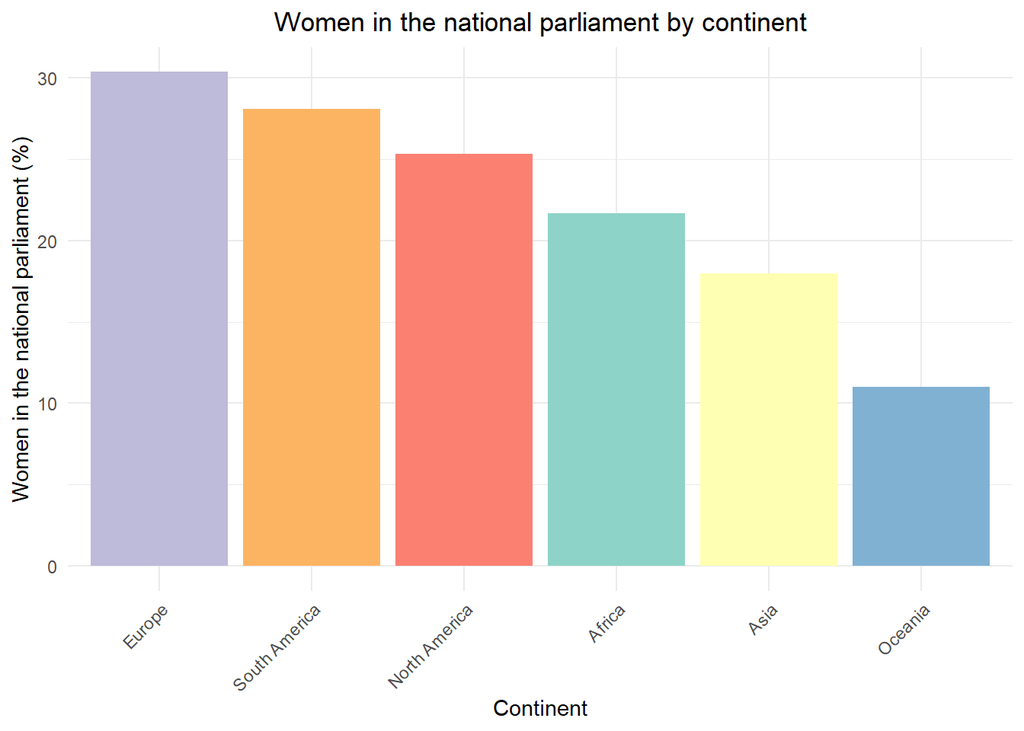

```r
#Situación imaginaria. Naciones Unidas está realizando un informe de revisión del cumplimiento de los ODS. Nos contactan para indagar en el objetivo número 5 -"lograr la igualdad entre los géneros y empoderar a todas las mujeres y las niñas"-.

#El subobjetivo 5.5 versa sobre "asegurar la participación plena y efectiva de las mujeres y la igualdad de oportunidades de liderazgo a todos los niveles decisorios en la vida política, económica y pública". Por ello, se solicita un gráfico que represente los escaños que ocupen las mujeres en el parlamento nacional según continente, así como, de manera más específica, el valor máximo por región mundial. Esto último tiene que presentarse de mayor a menor e indicando el continente en el que se encuentra cada región.

qog %>%
  filter(!is.na(continent)) %>%
  group_by(continent) %>%
  summarize(mean_womenparlament = mean(wdi_wip, na.rm = TRUE)) %>%

ggplot(aes(x = reorder(continent, -mean_womenparlament), y = mean_womenparlament, fill = continent)) +
  geom_col(show.legend = FALSE) +
  labs(
    title = "Women in the national parliament by continent",
    x = "Continent",
    y = "Women in the national parliament (%)"
  ) +
  theme_minimal() +
  theme(
    axis.text.x = element_text(angle = 45, hjust = 1),
    plot.title = element_text(hjust = 0.5)
  ) +
  scale_fill_brewer(palette = "Set3")
```

```r
qog %>%
  filter(!is.na(region1)) %>%
  group_by(region1) %>%
  filter(wdi_wip == max(wdi_wip, na.rm = TRUE)) %>%
  ungroup() %>%  #aquí ungroup sí es necesario
  select(continent, region1, wdi_wip) %>%
  arrange(desc(wdi_wip))
```

```
# A tibble: 22 × 3
   continent     region1         wdi_wip
   <chr>         <chr>             <dbl>
 1 Africa        Eastern Africa     61.2
 2 North America Caribbean          53.2
 3 South America South America      53.1
 4 Asia          Western Asia       50
 5 North America Central America    48.2
 6 Europe        Northern Europe    47.3
 7 Europe        Southern Europe    46.4
 8 Africa        Southern Africa    46.3
 9 Europe        Western Europe     42
10 Africa        Western Africa     41.8
# ℹ 12 more rows
```